# My quarto file

Author

Jane Doe

Published

July 23, 2025

I want this picture displayed in the margin

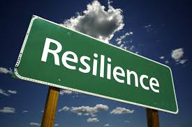

R Core Team. 2025. *R: A Language and Environment for Statistical Computing*. Vienna, Austria: R Foundation for Statistical Computing. https://www.R-project.org/.

Wickham, Hadley. 2016. *Ggplot2: Elegant Graphics for Data Analysis*. Springer-Verlag New York. https://ggplot2.tidyverse.org.

Epifania, Ottavia M, Pasquale Anselmi, and Egidio Robusto. 2024. “A Guided Tutorial on Linear Mixed-Effects Models for the Analysis of Accuracies and Response Times in Experiments with Fully Crossed Design.” *Psychological Methods*. https://doi.org/https://doi.org/10.1037/met0000708.

`ggplot2` is an R (R Core Team 2025) package developed by (Wickham 2016). Epifania, Anselmi, and Robusto (2024) published an interesting paper on Linear Mixed Effects Models.

First column, 4/12 of the total width

Second column, 8/12 of the total width

This is my first column!

And this is the second column

**chunk 1 show the code**

**begging of the summary**

```r
head(rock)
```

```
  area    peri     shape perm
1 4990 2791.90 0.0903296  6.3
2 7002 3892.60 0.1486220  6.3
3 7558 3930.66 0.1833120  6.3
4 7352 3869.32 0.1170630  6.3
5 7943 3948.54 0.1224170 17.1
6 7979 4010.15 0.1670450 17.1
```

**chunk 2 show the code**

**I want to see this specific code**

````markdown
```{r}
head(rock)
```
````

```
  area    peri     shape perm
1 4990 2791.90 0.0903296  6.3
2 7002 3892.60 0.1486220  6.3
3 7558 3930.66 0.1833120  6.3
4 7352 3869.32 0.1170630  6.3
5 7943 3948.54 0.1224170 17.1
6 7979 4010.15 0.1670450 17.1
```

**chunk 3 show the code**

**summary fonksiyonu argümanla kullanımı**

```r
summary(rock, digits = 2)
```

```
      area            peri          shape           perm
 Min.   : 1016   Min.   : 309   Min.   :0.09   Min.   :   6.3
 1st Qu.: 5305   1st Qu.:1415   1st Qu.:0.16   1st Qu.:  76.5
 Median : 7487   Median :2536   Median :0.20   Median : 130.5
 Mean   : 7188   Mean   :2682   Mean   :0.22   Mean   : 415.4
 3rd Qu.: 8870   3rd Qu.:3990   3rd Qu.:0.26   3rd Qu.: 777.5
 Max.   :12212   Max.   :4864   Max.   :0.46   Max.   :1300.0
```

[output not shown]